# analysis

Dataset Overview

This dataset contains information on beauty and fragrance products, including product names, brands, customer engagement metrics such as loves count, ratings, and the number of reviews.

```python
import pandas as pd

df = pd.read_csv("data/product_info.csv")
df.head()
```

|  | product_id | product_name | brand_id | brand_name | loves_count | rating | reviews | size | variation_type | variation_value | ... | online_only | out_of_stock | sephora_exclusive | highlights | primary_category | secondary_category | tertiary_category | child_count | child_max_price | child_min_price |
| --- | --- | --- | --- | --- | --- | --- | --- | --- | --- | --- | --- | --- | --- | --- | --- | --- | --- | --- | --- | --- | --- |
| 0 | P473671 | Fragrance Discovery Set | 6342 | 19-69 | 6320 | 3.6364 | 11.0 | NaN | NaN | NaN | ... | 1 | 0 | 0 | ['Unisex/ Genderless Scent', 'Warm &Spicy Scen... | Fragrance | Value & Gift Sets | Perfume Gift Sets | 0 | NaN | NaN |
| 1 | P473668 | La Habana Eau de Parfum | 6342 | 19-69 | 3827 | 4.1538 | 13.0 | 3.4 oz/ 100 mL | Size + Concentration + Formulation | 3.4 oz/ 100 mL | ... | 1 | 0 | 0 | ['Unisex/ Genderless Scent', 'Layerable Scent'... | Fragrance | Women | Perfume | 2 | 85.0 | 30.0 |
| 2 | P473662 | Rainbow Bar Eau de Parfum | 6342 | 19-69 | 3253 | 4.2500 | 16.0 | 3.4 oz/ 100 mL | Size + Concentration + Formulation | 3.4 oz/ 100 mL | ... | 1 | 0 | 0 | ['Unisex/ Genderless Scent', 'Layerable Scent'... | Fragrance | Women | Perfume | 2 | 75.0 | 30.0 |
| 3 | P473660 | Kasbah Eau de Parfum | 6342 | 19-69 | 3018 | 4.4762 | 21.0 | 3.4 oz/ 100 mL | Size + Concentration + Formulation | 3.4 oz/ 100 mL | ... | 1 | 0 | 0 | ['Unisex/ Genderless Scent', 'Layerable Scent'... | Fragrance | Women | Perfume | 2 | 75.0 | 30.0 |
| 4 | P473658 | Purple Haze Eau de Parfum | 6342 | 19-69 | 2691 | 3.2308 | 13.0 | 3.4 oz/ 100 mL | Size + Concentration + Formulation | 3.4 oz/ 100 mL | ... | 1 | 0 | 0 | ['Unisex/ Genderless Scent', 'Layerable Scent'... | Fragrance | Women | Perfume | 2 | 75.0 | 30.0 |

5 rows × 27 columns

```python
df.shape, df.columns
```

```
((8494, 27),
 Index(['product_id', 'product_name', 'brand_id', 'brand_name', 'loves_count',
        'rating', 'reviews', 'size', 'variation_type', 'variation_value',
        'variation_desc', 'ingredients', 'price_usd', 'value_price_usd',
        'sale_price_usd', 'limited_edition', 'new', 'online_only',
        'out_of_stock', 'sephora_exclusive', 'highlights', 'primary_category',
        'secondary_category', 'tertiary_category', 'child_count',
        'child_max_price', 'child_min_price'],
       dtype='object'))
```

```python
df.info()
df.describe()
```

```
<class 'pandas.core.frame.DataFrame'>
RangeIndex: 8494 entries, 0 to 8493
Data columns (total 27 columns):
 #   Column              Non-Null Count  Dtype
---  ------              --------------  -----
 0   product_id          8494 non-null   object
 1   product_name        8494 non-null   object
 2   brand_id            8494 non-null   int64
 3   brand_name          8494 non-null   object
 4   loves_count         8494 non-null   int64
 5   rating              8216 non-null   float64
 6   reviews             8216 non-null   float64
 7   size                6863 non-null   object
 8   variation_type      7050 non-null   object
 9   variation_value     6896 non-null   object
```

[output cut: 19 more lines]

|  | brand_id | loves_count | rating | reviews | price_usd | value_price_usd | sale_price_usd | limited_edition | new | online_only | out_of_stock | sephora_exclusive | child_count | child_max_price | child_min_price |
| --- | --- | --- | --- | --- | --- | --- | --- | --- | --- | --- | --- | --- | --- | --- | --- |
| count | 8494.000000 | 8.494000e+03 | 8216.000000 | 8216.000000 | 8494.000000 | 451.000000 | 270.000000 | 8494.000000 | 8494.000000 | 8494.000000 | 8494.000000 | 8494.000000 | 8494.000000 | 2754.000000 | 2754.000000 |
| mean | 5422.440546 | 2.917957e+04 | 4.194513 | 448.545521 | 51.655595 | 91.168537 | 20.207889 | 0.070285 | 0.071698 | 0.219096 | 0.073699 | 0.279374 | 1.631622 | 53.792023 | 39.665802 |
| std | 1709.595957 | 6.609212e+04 | 0.516694 | 1101.982529 | 53.669234 | 79.195631 | 24.327352 | 0.255642 | 0.258002 | 0.413658 | 0.261296 | 0.448718 | 5.379470 | 58.765894 | 38.685720 |
| min | 1063.000000 | 0.000000e+00 | 1.000000 | 1.000000 | 3.000000 | 0.000000 | 1.750000 | 0.000000 | 0.000000 | 0.000000 | 0.000000 | 0.000000 | 0.000000 | 3.000000 | 3.000000 |
| 25% | 5333.000000 | 3.758000e+03 | 3.981725 | 26.000000 | 25.000000 | 45.000000 | 8.000000 | 0.000000 | 0.000000 | 0.000000 | 0.000000 | 0.000000 | 0.000000 | 22.000000 | 19.000000 |
| 50% | 6157.500000 | 9.880000e+03 | 4.289350 | 122.000000 | 35.000000 | 67.000000 | 14.000000 | 0.000000 | 0.000000 | 0.000000 | 0.000000 | 0.000000 | 0.000000 | 32.000000 | 28.000000 |
| 75% | 6328.000000 | 2.684125e+04 | 4.530525 | 418.000000 | 58.000000 | 108.500000 | 25.000000 | 0.000000 | 0.000000 | 0.000000 | 0.000000 | 1.000000 | 1.000000 | 59.000000 | 42.000000 |
| max | 8020.000000 | 1.401068e+06 | 5.000000 | 21281.000000 | 1900.000000 | 617.000000 | 320.000000 | 1.000000 | 1.000000 | 1.000000 | 1.000000 | 1.000000 | 105.000000 | 570.000000 | 400.000000 |

```python
df.isna().sum().sort_values(ascending=False)
```

```
sale_price_usd        8224
value_price_usd       8043
variation_desc        7244
child_max_price       5740
child_min_price       5740
highlights            2207
size                  1631
variation_value       1598
variation_type        1444
tertiary_category      990
ingredients            945
rating                 278
reviews                278
secondary_category       8
sephora_exclusive        0
brand_id                 0
child_count              0
primary_category         0
new                      0
out_of_stock             0
online_only              0
limited_edition          0
brand_name               0
product_name             0
price_usd                0
loves_count              0
product_id               0
dtype: int64
```

What the data looks like

- Each row is one product/variation.
- Columns include product + brand details and customer engagement metrics (loves, rating, reviews).
- Some fields (like size/variation details) are missing for certain rows, which probably means those products don’t have that info available or don’t have variations listed.

```python
df["brand_name"].value_counts().head(10)
```

```
brand_name
SEPHORA COLLECTION         352
CLINIQUE                   179
Dior                       136
tarte                      131
NEST New York              115
Bumble and bumble          110
Kérastase                  108
TOM FORD                   100
Charlotte Tilbury           99
Anastasia Beverly Hills     95
Name: count, dtype: int64
```

```python
df["rating"].mean()
```

```
np.float64(4.194512889483933)
```

Summary Observation summary statistics:

- The majority of product ratings are above average and products are positively rated.
- Some brands are represented more than others, meaning they have more products in the dataset. - The number of reviews and loves varies wildly, suggesting that some products are far more popular than others on the platform.

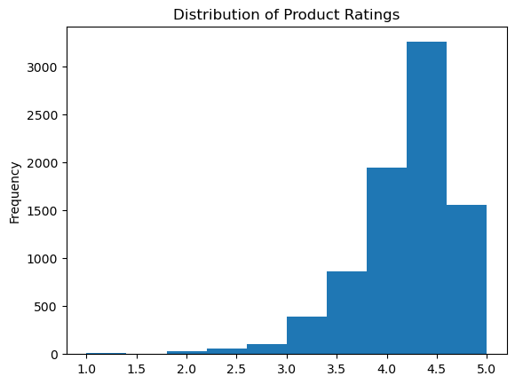

```python
df["rating"].plot(kind="hist", title="Distribution of Product Ratings")
```

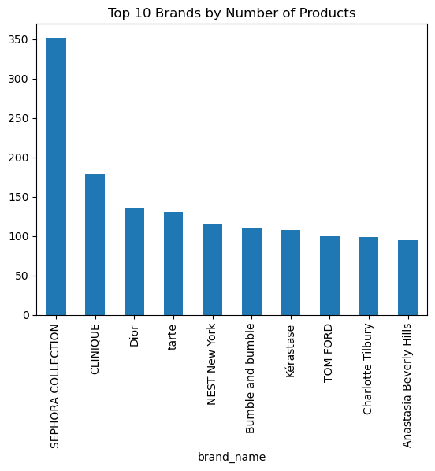

```python
df["brand_name"].value_counts().head(10).plot(
    kind="bar",
    title="Top 10 Brands by Number of Products"
)
```

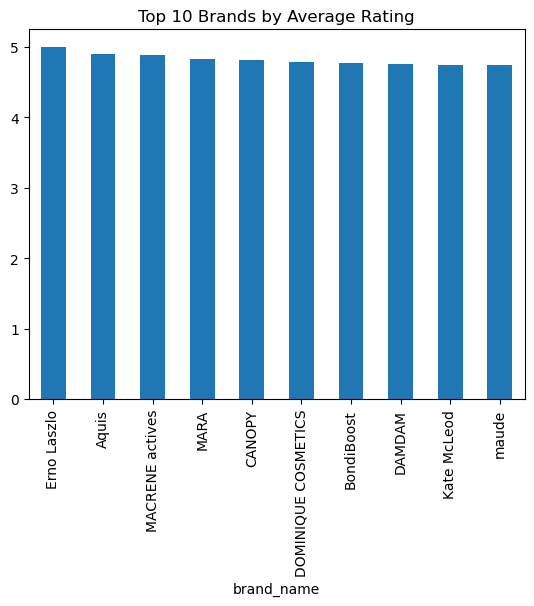

```python
df.groupby("brand_name")["rating"].mean().sort_values(ascending=False).head(10).plot(
    kind="bar",
    title="Top 10 Brands by Average Rating"
)
```

Graph Overview

graph 1 shows the distribution of product ratings across the dataset. Most products are rated between 4.0 and 5.0, indicating that customer feedback is generally positive. Very few products have low ratings, showing that poorly rated products are less common.

graph 3 this chart displays the top 10 brands ranked by their average product rating. Brands with higher average ratings tend to have more consistently well reviewed products. This shows that customer satisfaction may vary by brand, not just by individual product.

Insights